# Atividade 4 - R Markdown

Gustavo Viana de Freitas

23/09/2021

# Relatório R Markdown Atividade 3 - Acesso a Banco de Dados Abertos

# Disciplina **Ferramentas em Ciência Colaborativa e Banco de dados**

### Programa de Pós-Graduação em Ecologia e Recursos Naturais - PPGERN

### Universidade Estadual do Norte Fluminense Darcy Ribeiro

#### Contexto

A Atividade 3 consistiu em extrair dados de uma espécie da base de dados do GBIF.  
O roteiro da atividade 3 pode ser visto no [Repositório da Disciplina](https://cammcordeiro.github.io/ciencia_colab/index.html).

A espécie escolhida foi a bromélia *Alcantarea imperialis* (Carrière) Harms.

O passo a passo abaixo refere-se a todo o procedimento de extração e observação dos dados.

1. Carregando todos os pacotes necessários
   1. Utilizando a função `require`.

```r
require(tidyverse)
require(rgbif)
require(ggmap)
require(maps)
require(mapdata)
require(scrubr)
require(CoordinateCleaner)
```

2. Importando os dados da espécie da base do GBIF e verificando suas características
   1. Utilizando a função `occ_data`.

```r
alcantarea_gbif <- occ_data(scientificName = "Alcantarea imperialis",
                      hasCoordinate = TRUE,
                      hasGeospatialIssue=FALSE)

head(alcantarea_gbif, 10)
```

```
## $meta
## $meta$offset
## [1] 0
##
## $meta$limit
## [1] 300
##
## $meta$endOfRecords
## [1] TRUE
##
## $meta$count
## [1] 27
##
##
## $data
## # A tibble: 27 x 103
##    key        scientificName  decimalLatitude decimalLongitude issues datasetKey
##    <chr>      <chr>                     <dbl>            <dbl> <chr>  <chr>
##  1 3330791691 Alcantarea imp~           -23.6            -46.6 cdrou~ 50c9509d-~
##  2 3112722380 Alcantarea imp~           -23.6            -46.6 cdrou~ 50c9509d-~
##  3 3355490453 Alcantarea imp~           -22.3            -42.6 cdrou~ 50c9509d-~
##  4 2619907376 Alcantarea imp~           -27.8            -48.5 cdrou~ 50c9509d-~
##  5 3337771400 Alcantarea imp~           -22.3            -42.5 cdrou~ 50c9509d-~
##  6 1423924431 Alcantarea imp~           -22.0            -43.3 cdrou~ 4300f8d5-~
##  7 1424239003 Alcantarea imp~           -22.4            -43.2 cdrou~ 4300f8d5-~
##  8 2302386808 Alcantarea imp~           -22.5            -43.2 cdrou~ 15e887a4-~
##  9 2452926872 Alcantarea imp~           -22.5            -43.2 gass8~ 17efa320-~
## 10 2452927151 Alcantarea imp~           -22.5            -43.2 gass8~ 17efa320-~
## # ... with 17 more rows, and 97 more variables: publishingOrgKey <chr>,
## #   installationKey <chr>, publishingCountry <chr>, protocol <chr>,
## #   lastCrawled <chr>, lastParsed <chr>, crawlId <int>,
## #   hostingOrganizationKey <chr>, basisOfRecord <chr>, occurrenceStatus <chr>,
## #   taxonKey <int>, kingdomKey <int>, phylumKey <int>, classKey <int>,
## #   orderKey <int>, familyKey <int>, genusKey <int>, speciesKey <int>,
## #   acceptedTaxonKey <int>, acceptedScientificName <chr>, kingdom <chr>, ...
```

```r
# Checando Dimensões
dim(alcantarea_gbif )
```

[output not shown]

```r
dim(alcantarea_gbif$data)
```

```
## [1]  27 103
```

```r
# Checando Campos
alcantarea_gbif$data %>% names
```

```
##   [1] "key"
##   [2] "scientificName"
##   [3] "decimalLatitude"
##   [4] "decimalLongitude"
##   [5] "issues"
##   [6] "datasetKey"
##   [7] "publishingOrgKey"
##   [8] "installationKey"
##   [9] "publishingCountry"
##  [10] "protocol"
##  [11] "lastCrawled"
##  [12] "lastParsed"
##  [13] "crawlId"
##  [14] "hostingOrganizationKey"
##  [15] "basisOfRecord"
```

[output cut: 88 more lines]

3. Observando os problemas reportados a partir da extração desses dados (issues)

```r
### Problemas reportados
gbif_issues()
```

```
##           code                                             issue
## 1          bri                           BASIS_OF_RECORD_INVALID
## 2          ccm                        CONTINENT_COUNTRY_MISMATCH
## 3          cdc                CONTINENT_DERIVED_FROM_COORDINATES
## 4        conti                                 CONTINENT_INVALID
## 5         cdiv                                COORDINATE_INVALID
## 6        cdout                           COORDINATE_OUT_OF_RANGE
## 7        cdrep                            COORDINATE_REPROJECTED
## 8       cdrepf                    COORDINATE_REPROJECTION_FAILED
## 9       cdreps                COORDINATE_REPROJECTION_SUSPICIOUS
## 10     cdround                                COORDINATE_ROUNDED
## 11     cucdmis                       COUNTRY_COORDINATE_MISMATCH
## 12        cudc                  COUNTRY_DERIVED_FROM_COORDINATES
## 13        cuiv                                   COUNTRY_INVALID
## 14         cum                                  COUNTRY_MISMATCH
```

[output cut: 285 more lines]

```r
issues_gbif<- alcantarea_gbif$data$issues %>%
  #unique() %>%
  strsplit(.,"[,]") %>%
  unlist() %>%
  unique()
### Gerou e separou vários issues

## Ver quais problemas foram baixados no dataset da espécie em questão.
gbif_issues() %>% head %>%
  data.frame() %>%
  filter(code %in% issues_gbif)
```

```
## [1] code        issue       description type
## <0 linhas> (ou row.names de comprimento 0)
```

```r
gbif_issues() %>%
  data.frame() %>%
  filter(code %in% issues_gbif)
```

```
##        code                                            issue
## 1     cdrep                           COORDINATE_REPROJECTED
## 2   cdround                               COORDINATE_ROUNDED
## 3     elmms                        ELEVATION_MIN_MAX_SWAPPED
## 4    gass84                     GEODETIC_DATUM_ASSUMED_WGS84
## 5  muluriiv                           MULTIMEDIA_URI_INVALID
## 6    rdativ                            RECORDED_DATE_INVALID
## 7     osiic OCCURRENCE_STATUS_INFERRED_FROM_INDIVIDUAL_COUNT
## 8    ambcol                             AMBIGUOUS_COLLECTION
## 9   colmafu                           COLLECTION_MATCH_FUZZY
## 10   inmafu                          INSTITUTION_MATCH_FUZZY
## 11   inmano                           INSTITUTION_MATCH_NONE
##                                                                                                                                 description
## 1                                            The original coordinate was successfully reprojected from a different geodetic datum to WGS84.
## 2                                                                                   Original coordinate modified by rounding to 5 decimals.
```

[output cut: 21 more lines]

4. Selecionando Campos de Interesse nos dados

```r
## Campos de Interesse
alcantarea_gbif1 <- alcantarea_gbif$data %>%
  dplyr::select(scientificName, acceptedScientificName, decimalLatitude, decimalLongitude,
                issues, basisOfRecord, occurrenceStatus, rightsHolder,
                datasetName, recordedBy, country)

alcantarea_gbif1 <- alcantarea_gbif1 %>%
  distinct()


# checar niveis dos fatores
lapply(alcantarea_gbif1, unique)
```

```
## $scientificName
## [1] "Alcantarea imperialis (Carrière) Harms"
## [2] "Vriesea imperialis Carrière"
## [3] "Vriesea gigantea Lem."
##
## $acceptedScientificName
## [1] "Alcantarea imperialis (Carrière) Harms"
##
## $decimalLatitude
##  [1] -23.63927 -23.63925 -22.32271 -27.78026 -22.31007 -22.02056 -22.40278
##  [8] -22.51139 -22.53586 -22.36914 -25.44194 -21.68444 -21.68306 -22.50885
## [15] -22.50500 -25.90000 -26.98000 -23.00000 -10.83390
##
## $decimalLongitude
##  [1] -46.62702 -46.62175 -42.57988 -48.53917 -42.49706 -43.30444 -43.19861
```

[output cut: 71 more lines]

5. Observando os problemas reportados a partir da extração desses dados

```r
### Problemas não reportados
# Investigar niveis suspeitos, caso essa espécie fosse distribuída em várias localidades
##
alcantarea_gbif1 %>%
  distinct(country) %>%
  pull()
```

```
## [1] "Brazil"
```

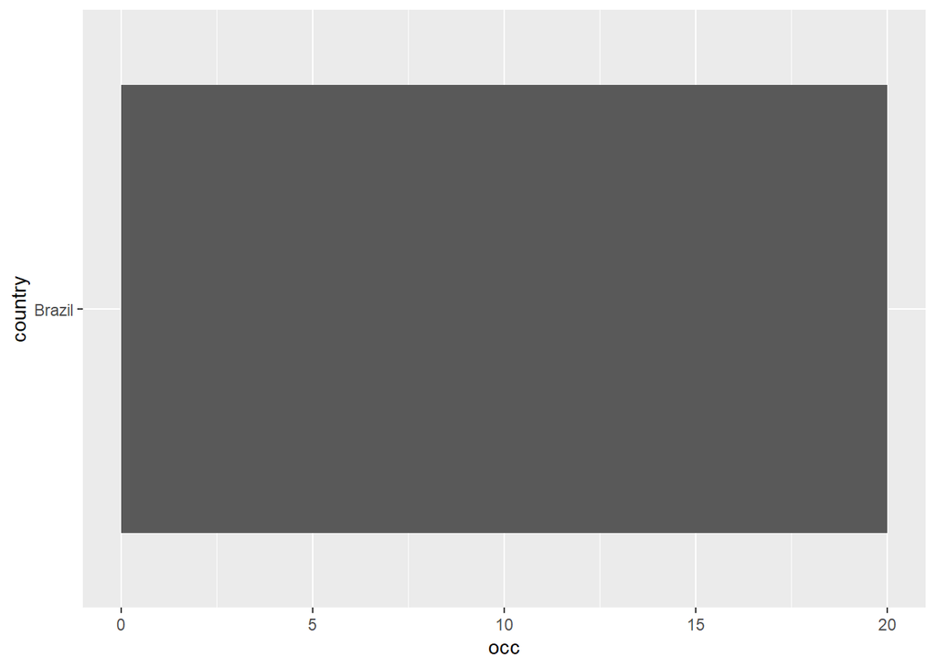

```r
# Só tem no Brasil mesmo... aqui no caso da Dory, tinha vários países de ocorrencia que não tem a spp
alcantarea_gbif1 %>%
  group_by(country) %>%
  summarise(occ = length(scientificName)) %>%
  ggplot(aes(occ, y=country)) +
  geom_bar(stat = 'identity')
```

```r
### OBS: deu uma barra grande pq só tem o Brasil mesmo.

# Fonte das regioes erradas
# Não se aplicaria aqui, já que somente há uma localidade
alcantarea_gbif1 %>%
  filter(country %in% c("Brazil")) %>%
  distinct(datasetName)
```

```
## # A tibble: 8 x 1
##   datasetName
##   <chr>
## 1 "iNaturalist research-grade observations"
## 2 "RB - Rio de Janeiro Botanical Garden Herbarium Collection"
## 3  <NA>
## 4 "SP - Herbário do Estado \"Maria Eneyda P. Kaufmann Fidalgo\" - Coleção de Fa~
## 5 "FURB - Herbário Dr. Roberto Miguel Klein"
## 6 "Vascular plants"
## 7 "NMNH Extant Biology"
## 8 "Flowers TCN"
```

```r
## O script acima gerou um NA, resolvi retirá-lo
alcantarea_gbif1 %>%
  filter(datasetName %in% c("NA"))
```

```
## # A tibble: 4 x 11
##   scientificName    acceptedScientifi~ decimalLatitude decimalLongitude issues
##   <chr>             <chr>                        <dbl>            <dbl> <chr>
## 1 Alcantarea imper~ Alcantarea imperi~           -22.5            -43.2 cdround~
## 2 Alcantarea imper~ Alcantarea imperi~           -25.4            -49.2 cdround~
## 3 Vriesea imperial~ Alcantarea imperi~           -22.5            -43.2 cdround~
## 4 Vriesea imperial~ Alcantarea imperi~           -23              -43.4 gass84,~
## # ... with 6 more variables: basisOfRecord <chr>, occurrenceStatus <chr>,
## #   rightsHolder <chr>, datasetName <chr>, recordedBy <chr>, country <chr>
```

```r
# Filtrar todas do dataset suspeito
alcantarea_gbif_ok <- alcantarea_gbif1 %>%
  filter(!datasetName %in% c("NA"))
```

6. Checando os pontos de ocorrência da espécie pela confecção de um mapa

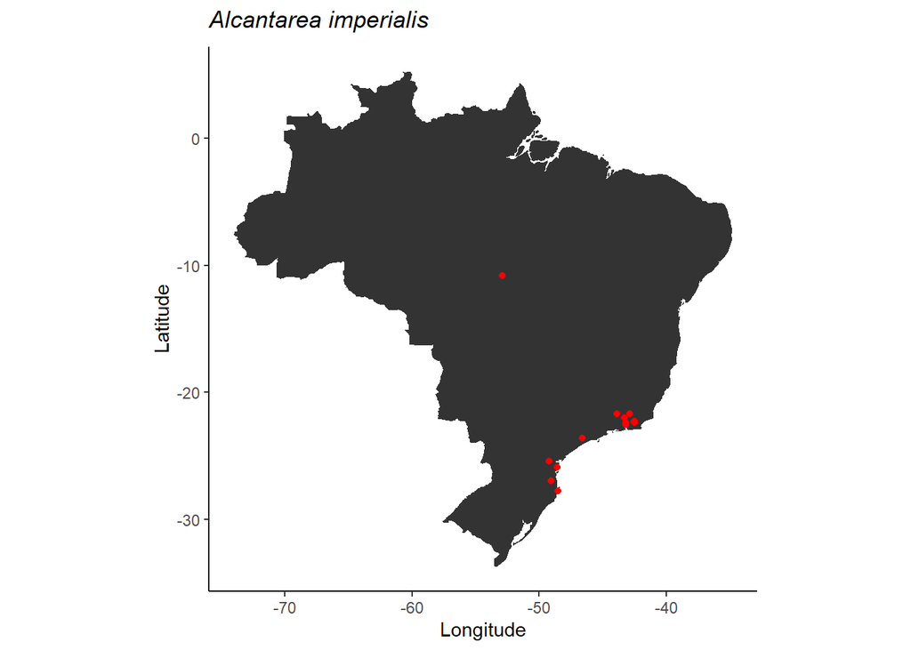

```r
World<-map_data('world')
Brazil <- map_data('world', region='Brazil')
# checar pontos
ggplot() +
  geom_polygon(data = Brazil, aes(x = long, y = lat, group = group)) +
  coord_fixed() +
  theme_classic() +
  geom_point(data = alcantarea_gbif_ok, aes(x = decimalLongitude, y = decimalLatitude), color = "red") +
  labs(x = "Longitude", y = "Latitude", title = expression(italic("Alcantarea imperialis")))
```

```r
# Checar profundidade - Não se aplicou no meu porque não tenho uma variável contínua de interesse.
# A maioria está com NAs como elevação. No exemplo da aula, a variável foi depth (profundidade)
```

**Observação**: Nesse relatório não foi reportado nada relacionado ao OBIS, uma vez que esse banco de dados é mais aplicado para dados marinhos. Portanto, todo o script e passo a passo relacionado ao OBIS não foi reportado aqui. Pacotes relacionados ao obis também não foram carregados e utlizados.

7. Mapeando ocorrências e gerando planilha de dados de interesse

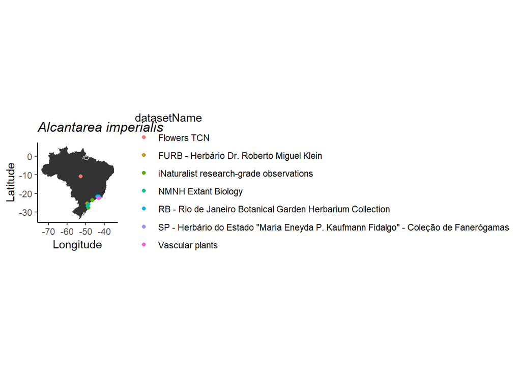

```r
all_data <- bind_rows(alcantarea_gbif_ok %>%
                        mutate(repo = paste0("gbif", row.names(.)))) %>%
  column_to_rownames("repo") %>%
  dplyr::select(scientificName, acceptedScientificName, decimalLatitude, decimalLongitude,
                occurrenceStatus, country) %>%
  distinct() %>%
  rownames_to_column("occ") %>%
  separate(col = "occ", into = c("datasetName", "rn"), sep = 4) %>%
  mutate(scientificName = "Alcantarea imperialis") %>%
  dplyr::select(-rn)

# mapear ocorrencias
ggplot() +
  geom_polygon(data = Brazil, aes(x = long, y = lat, group = group)) +
  coord_fixed() +
  theme_classic() +
  geom_point(data = alcantarea_gbif_ok, aes(x = decimalLongitude, y = decimalLatitude, color = datasetName)) +
  #theme(legend.title = element_blank()) +
  labs(x = "Longitude", y = "Latitude", title = expression(italic("Alcantarea imperialis")))
```

```r
## Aqui, caso eu quisesse gerar a planilha com as informações selecionadas
write.csv(all_data, "Alcantarea_imperialis_info_gbif.csv", row.names = FALSE)
```

7. Parte extra: em caso de classificar automaticamente os pontos

```r
# funcao para classificar ocorrencias suspeitas
flag_outlier <- function(df, species){

  # funcao para classificar ocorrencias suspeitas
  # baseada no calculo do centroide de todas ocorrencias
  # indica como 'check' as ocorrencias que tem distancias até o centroide
  # acima do 90th quantil (default) das distancias calculadas

  dados <- df %>%
    dplyr::filter(scientificName == species);

  dados2 <- geosphere::distVincentyEllipsoid(
    dados %>%
      summarise(centr_lon = median(decimalLongitude),
                centr_lat = median(decimalLatitude)),
    dados %>%
      dplyr::select(decimalLongitude, decimalLatitude)
  ) %>%
    bind_cols(dados) %>%
    rename(dist_centroid = '...1') %>%
    mutate(flag = ifelse(dist_centroid < quantile(dist_centroid, probs = 0.9), "OK",
                         ifelse(dist_centroid >= quantile(dist_centroid, probs = 0.90) & dist_centroid < quantile(dist_centroid, probs = 0.95), "check > Q90",
                                ifelse(dist_centroid >= quantile(dist_centroid, probs = 0.95), "check > Q95", "OK"))))

  # mutate(flag = ifelse(dist_centroid > quantile(dist_centroid, probs = prob), "check", "OK"))

  print(dados2)

}

#Distâncias acima do 90° percentil, são consideradas como dados suspeitos


# Classificar ocorrências
marcados <- alcantarea_gbif$data %>%
  data.frame() %>%
  dplyr::select(scientificName, decimalLongitude, decimalLatitude, datasetName) %>%
  distinct() %>%
  flag_outlier(., "Alcantarea imperialis (Carrière) Harms")
```

```
## * NA -> ...1
```

```
##    dist_centroid                         scientificName decimalLongitude
## 1      367066.26 Alcantarea imperialis (Carrière) Harms        -46.62702
## 2      366564.77 Alcantarea imperialis (Carrière) Harms        -46.62175
## 3       75153.51 Alcantarea imperialis (Carrière) Harms        -42.57988
## 4      795809.68 Alcantarea imperialis (Carrière) Harms        -48.53917
## 5       83793.23 Alcantarea imperialis (Carrière) Harms        -42.49706
## 6       42324.64 Alcantarea imperialis (Carrière) Harms        -43.30444
## 7       10897.41 Alcantarea imperialis (Carrière) Harms        -43.19861
## 8       17737.79 Alcantarea imperialis (Carrière) Harms        -43.17778
## 9       19711.66 Alcantarea imperialis (Carrière) Harms        -43.17725
## 10      83251.38 Alcantarea imperialis (Carrière) Harms        -42.49683
## 11     691503.09 Alcantarea imperialis (Carrière) Harms        -49.23889
## 12     691503.09 Alcantarea imperialis (Carrière) Harms        -49.23889
## 13      90141.59 Alcantarea imperialis (Carrière) Harms        -42.89361
## 14      99732.15 Alcantarea imperialis (Carrière) Harms        -43.88528
```

[output cut: 49 more lines]

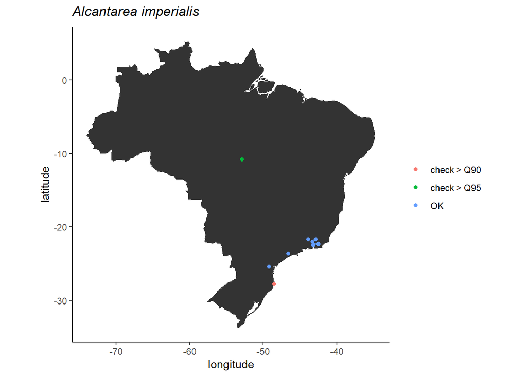

```r
# Mapa
ggplot() +
  geom_polygon(data = Brazil, aes(x = long, y = lat, group = group)) +
  coord_fixed() +
  theme_classic() +
  geom_point(data = marcados,
             aes(x = decimalLongitude, y = decimalLatitude,
                 color = flag)) +
  theme(legend.title = element_blank()) +
  labs(x = "longitude", y = "latitude",
       title = expression(italic("Alcantarea imperialis")))
```

```r
### Duas ocorrências estão suspeitas e de fato, pelo conhecimento da spp, a que está mais
### suspeita é o ponto marcado na região centro-oeste/norte.
### O outro ponto é o rosa, que se encontra no sul.
### A espécie tem distribuição RJ/ES/SP
```

8. Checando essas ocorrências suspeitas e plotando com o pacote `scrubr`

```r
# Usando os dados com flag
data_scrubr <- marcados %>%
  dframe() %>%
  coord_impossible() %>%
  coord_incomplete() %>%
  coord_unlikely() %>%
  dedup()
```

```
## Assuming 'decimalLatitude' is latitude
```

```
## Assuming 'decimalLongitude' is longitude
```

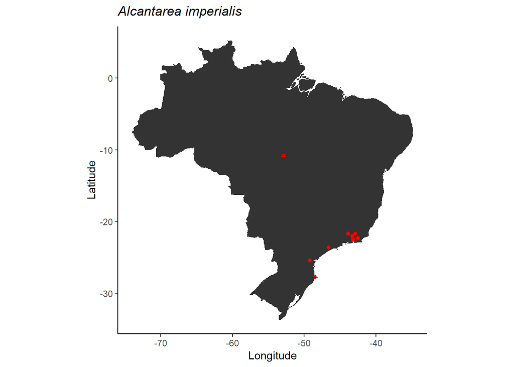

```r
# Mapa
ggplot() +
  geom_polygon(data = Brazil, aes(x = long, y = lat, group = group)) +
  coord_fixed() +
  theme_classic() +
  geom_point(data = data_scrubr,
             aes(x = decimalLongitude, y = decimalLatitude),
             color = "red") +
  geom_point(data = marcados %>%
               filter(flag != "OK"),
             aes(x = decimalLongitude, y = decimalLatitude),
             color = "blue", shape = 3) +
  theme(legend.title = element_blank()) +
  labs(x = "Longitude", y = "Latitude",
       title = expression(italic("Alcantarea imperialis")))
```

```r
### Duas ocorrências suspeitas marcadas com uma cruz e retirou as duplicadas
```

9. Checando as coordenadas comparando com as coordenadas do GBIF

```r
#Vai checar algumas coordenadas e comparar com as coordenadas do gbif
flags <-
  clean_coordinates(
    x = marcados,
    lon = "decimalLongitude",
    lat = "decimalLatitude",
    species = "scientificName",
    tests = c("equal", "gbif",
              "zeros", "seas")
  )
```

```
## Testing coordinate validity
```

```
## Flagged 0 records.
```

```
## Testing equal lat/lon
```

```
## Flagged 0 records.
```

```
## Testing zero coordinates
```

```
## Flagged 0 records.
```

```
## Testing sea coordinates
```

```
## Testing GBIF headquarters, flagging records around Copenhagen
```

```
## Flagged 0 records.
```

```
## Flagged 0 of 15 records, EQ = 0.
```

```r
## Não encontrou problemas como foi explicado na aula da disciplina
```